# Exercise 6: Differential expression with the limma package

Heeju Noh

November 16, 2016

#### 0. Generating Simulated Data

Loading the limma package and a paramter setup:

```r
library("limma")

nGenes <- 10000                   # number of "features"
nSamples <- 6                     # number of samples (split equal in 2 groups)
pDiff <- .1                       # percent of genes "differential
grp <- rep(0:1,each=nSamples/2)   # dummy variable for exp. group
trueFC <- 2                    # log-fold-change of truly DE

d0 <- 1
s0 <- 0.8
sd <- s0*sqrt(d0/rchisq(nGenes,df=d0))  # dist'n of s.d.
```

#### **Question 1. The distribution of “true” s.d.**

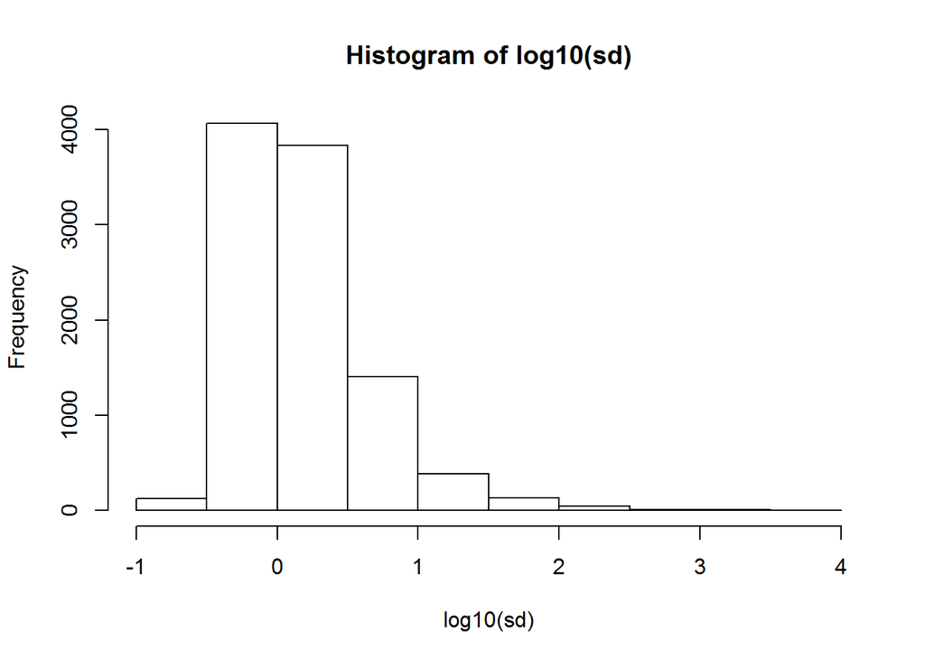

Minimum value in s.d.:

```
## [1] 0.2200215
```

Maximum value in s.d.:

```
## [1] 3690.387
```

```r
y <- matrix(rnorm(nGenes*nSamples,sd=sd),nr=nGenes,nc=nSamples) # Generating (null) data following the normal distribution with the standard deviation for each gene.

indD <- 1:floor(pDiff*nGenes) # 1 to 10% of the number of genes to be differentially expressed
diff <- sample(c(-1,1),max(indD),replace=TRUE)*trueFC # choose either 2 (positively differentially expressed) or -2 (negatively difeerentially expressed) randomly
y[indD,grp==1] <- y[indD,grp==1] + diff # In group 1 (treated samples), 1 to 1000 (10%) genes are differentially expressed postively or negatively in addition to some noise generated already in y
```

#### **Question 2. Simulated data**

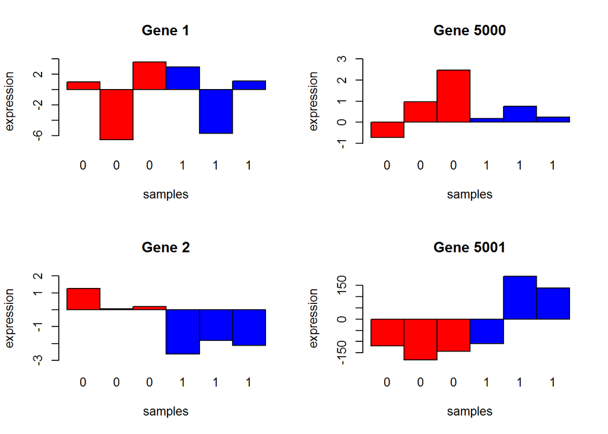

#### **Question 3. Design matrix**

```r
design <- model.matrix(~grp)
print(design)
```

```
##   (Intercept) grp
## 1           1   0
## 2           1   0
## 3           1   0
## 4           1   1
## 5           1   1
## 6           1   1
## attr(,"assign")
## [1] 0 1
```

Design matrix represents indicator variables in a linear model. For example, in this case, the first column indicates the intercept of the linear model, and the second column indicates the additional variable presented in group1 to explain the change of expressions from group0 to group1.

```r
fit <- lmFit(y,design)
fit <- eBayes(fit)
```

#### **Question 4. Calculating the classical 2-sample t-test**

```r
classicalt <- apply(y,1,function(x) t.test(x~grp)$statistic)
```

#### **Question 5. Statistica summaries of t-scores and logFC from limma and t-test results from t.test**

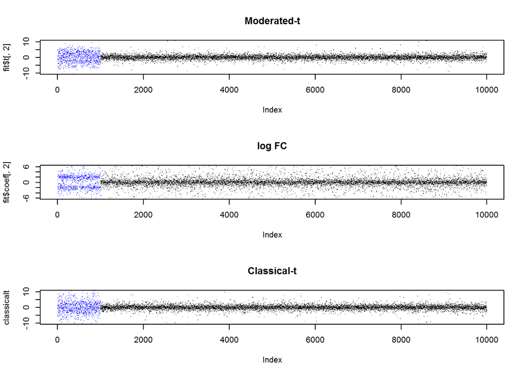

```r
cols <- rep("black",nrow(y))
cols[indD] <- "blue"

par(mfrow=c(3,1))
plot( fit$t[,2], col=cols, ylim=c(-10,10), pch=".", main="Moderated-t" )
plot( fit$coef[,2], col=cols, ylim=c(-6,6), pch=".", main="log FC" )
plot( classicalt, col=cols, ylim=c(-10,10), pch=".", main="Classical-t" )
```

First, coefficients in *fit* variable represent the mean expression changes between group0 and group1 by linear fit. Therefore, the coefficients in the second plot shows mostly 2 or -2 in gene 1-1000 and around 0 in gene > 1000. Through two different analyses of t-test, it was observed that the t-scores calcuated by *t.test()* show larger vairance than those from limma *fit*, which means much more data are not significant.

#### **Question 6. Somparing methods by statistica analysis**

[figure not shown]

```r
par(mfrow=c(1,1))
v1 <- sort(abs(fit$coefficients[,2]),decreasing=TRUE,index.return=TRUE)
v2 <- sort(abs(fit$t[,2]),decreasing=TRUE,index.return=TRUE)
v3 <- sort(abs(classicalt),decreasing=TRUE,index.return=TRUE)

P <- floor(pDiff*nGenes)
TP1 <- cumsum(as.numeric(v1$ix<=P))
TP2 <- cumsum(as.numeric(v2$ix<=P))
TP3 <- cumsum(as.numeric(v3$ix<=P))
TPR1 <- TP1/P
TPR2 <- TP2/P
TPR3 <- TP3/P

N <- nGenes-P
FP1 <- cumsum(as.numeric(v1$ix>P))
FP2 <- cumsum(as.numeric(v2$ix>P))
FP3 <- cumsum(as.numeric(v3$ix>P))
FPR1 <- FP1/N
FPR2 <- FP2/N
FPR3 <- FP3/N

plot(FPR1,TPR1,type = "l", xlim=c(0,1), ylim=c(0,1),xlab="FPR",ylab="TPR")
lines(FPR2,TPR2,col="red")
lines(FPR3,TPR3,col="blue")
title(main="ROC")
legend(0.5,0.5, c("logFC", "fit$coef", "classical-t"), lty=c(1,1), col = c("black","red","blue"),box.lwd=0.3)
```

```r
library(flux) #_flux_ package was used for using _auc()_ function
print(auc(FPR1,TPR1))
```

```
## [1] 0.7784913
```

```r
print(auc(FPR2,TPR2))
```

```
## [1] 0.8138291
```

```r
print(auc(FPR3,TPR3))
```

```
## [1] 0.7943261
```

#### **Question 7. Parameters affecting the performance of the methods**

As increasing number of samples from 6 to 50 which means increasing replicates, the performance by t-scores from both limma and classical method converges. On the other hand, the threshold of DE and the noise variance affect the results by logFC. The higher threshold of DE and smaller noise variance, the higher performance by logFC although the results by t-tests were still better. Finally, I could not observe a significant difference in results when varing the number of DE genes.